# Disney

Yuting Ma

12/18/2017

# I. Project Overview

Branding, as an important aspect of a company’s value, develops from advertising, product diferrenciation, customer loyalty and many factors. As the social media develops, consumers’ perception of the brand has become an increasingly important factor for valueing a brand, as well as for managment to monitor their performance and apply marketing strategy. This project analyzes the consumers’ perception for Walt Disney Company using Tweeter.

# II. Company Overview

The Walt Disney Company is an American diversified multinational mass media and entertainment conglomerate, and is the world’s second largest media conglomerate in terms of revenue. Some of the big events for the company this year is the acquisition of part of 21st Centry Fox, the announcement of the Chiness actress Yifei Liu as cast for the Mulan movie, and the release of the new movie Coco. The project captures and analyzes 15,000 of the golbal tweets in Enlish with keyword “Disney” as of December 14, 2017.

# III. Data Collection and Cleaning

## Data Collection

The tweeter data was collected with the TwitterR package, which searches for Tweets and the user information through Tweeter App.

The data collection process starts with searching for any tweets with keyword “Disney” from November 11, 2017. The project tries to capture the time trend of consumers’ perception, however, due to the search limits imposed by Disney, the tweets are concentrated on the date of December 14, 2017.

# Data Cleanning

As shown below: user created information usually *** contains a lot of non English character

[output not shown]

[output cut: 560 more lines]

# Data Summary

```r
# Data Summary
# tweets.df %>%
#     group_by(location) %>%
#       summarise(Num_Tweets = count(retweetCount),
#                 Retweet_Percent = sum(retweetCount) / count(retweetCount),
#                 Avg_Num_Retweet = mean(retweetCount)
#             ) -> s
# s
```

[figure not shown]

# Word Frequencies

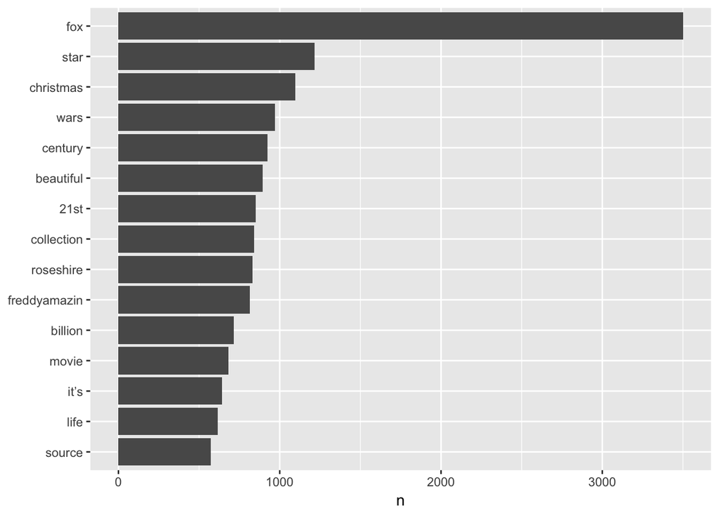

```r
text.df <- data_frame(user = tweets.df$screenName,
                      text = tweets.df$text,
                      location = tweets.df$location)

tidy.text <- unnest_tokens(text.df, word, text)

custom_stop_words <- bind_rows(data_frame(word = c("disney", "https", "disney's", "t.co", "rt", "6aue21xvif", "it's", "deal", "hgpmzy40z", "qbfzwwcjw", "40", "75", "it", "set", "assets"),
                                          lexicon = "custom"),
                               stop_words)

tidy.text <- tidy.text %>% anti_join(custom_stop_words)

word.freq <- tidy.text %>% count(word, sort=TRUE)

word.freq %>%
  filter(n > 550) %>%
  mutate(word = reorder(word, n)) %>%
  ggplot(aes(word, n)) +
  geom_col() +
  xlab(NULL) +
  coord_flip()
```

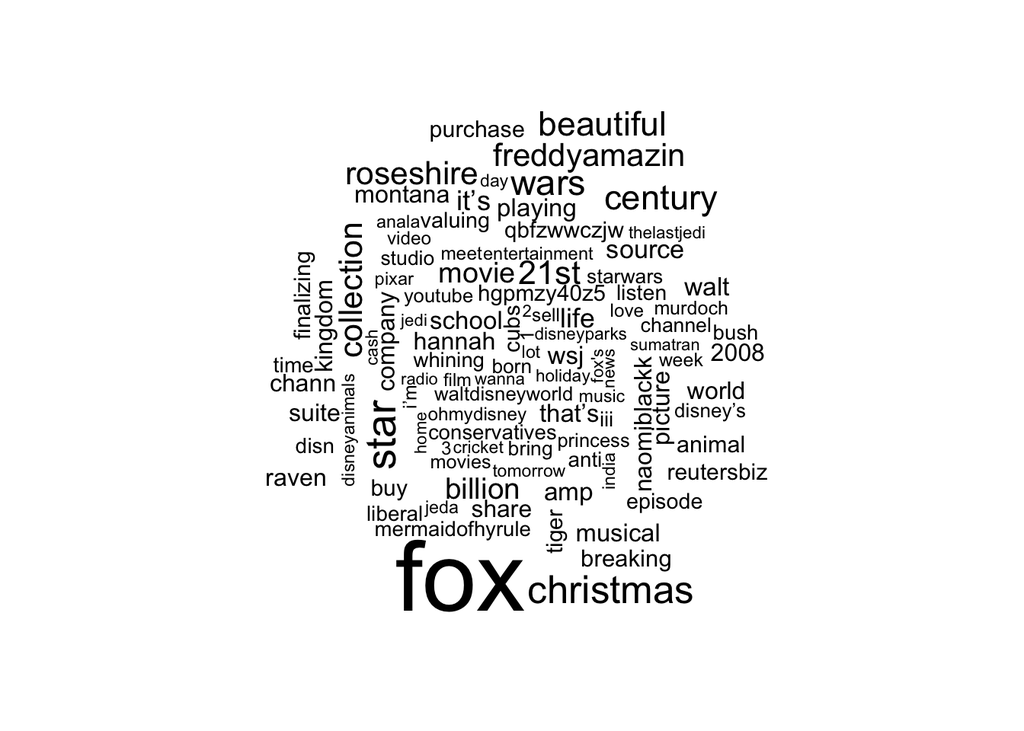

```r
tidy.text %>%
  count(word) %>%
  with(wordcloud(word, n, max.words = 100))
```

# Sentiment

```
## # A tibble: 2,476 x 2
##          word score
##         <chr> <int>
##  1    abandon    -2
##  2  abandoned    -2
##  3   abandons    -2
##  4   abducted    -2
##  5  abduction    -2
##  6 abductions    -2
##  7      abhor    -3
##  8   abhorred    -3
##  9  abhorrent    -3
## 10     abhors    -3
## # ... with 2,466 more rows
```

```
## # A tibble: 6,788 x 2
##           word sentiment
##          <chr>     <chr>
##  1     2-faced  negative
##  2     2-faces  negative
##  3          a+  positive
##  4    abnormal  negative
##  5     abolish  negative
##  6  abominable  negative
##  7  abominably  negative
##  8   abominate  negative
##  9 abomination  negative
## 10       abort  negative
## # ... with 6,778 more rows
```

```
## # A tibble: 13,901 x 2
##           word sentiment
##          <chr>     <chr>
##  1      abacus     trust
##  2     abandon      fear
##  3     abandon  negative
##  4     abandon   sadness
##  5   abandoned     anger
##  6   abandoned      fear
##  7   abandoned  negative
##  8   abandoned   sadness
##  9 abandonment     anger
## 10 abandonment      fear
## # ... with 13,891 more rows
```

[figure not shown]

```r
# Graph User
CA_center <- as.numeric(geocode("California"))
CAMap <- get_googlemap("California", zoom = 6, maptype = "roadmap", crop = FALSE)
CA <- ggmap(CAMap) +
  geom_point(aes(x=lon, y=lat), col=ifelse(((total$sentiment>=0)),"brown1", "blue"), data=total, alpha=0.4, size=total$sentiment)
CA
```

```r
# Graph
pal1 <- colorNumeric(palette = "Oranges",domain = total$sentiment)

leaflet(total) %>% addTiles() %>%
#  setView(lng = -103.85, lat = 37.45, zoom = 3) %>%
  addProviderTiles("Esri.WorldImagery") %>%
  addCircleMarkers(
    lng = total$lon,
    lat = total$lat,
    radius = 1.2,
    color = pal1(total$sentiment),
    opacity = 0.6,
    fill = TRUE,
    fillColor = pal1(total$sentiment),
    stroke = TRUE,
    fillOpacity = 0.6,
    label = NULL)
```

[interactive chart not shown]

```r
pal1 <- colorNumeric(palette = "Oranges",domain = total$sentiment)

leaflet(total) %>% addTiles() %>%
  setView( lng = 39.63, lat = -95.12, zoom = 5 ) %>%
  addProviderTiles("Esri.WorldImagery") %>%
  addCircleMarkers(
    lng = total$lon,
    lat = total$lat,
    radius = 1.2,
    color = pal1(total$sentiment),
    opacity = 0.6,
    fill = TRUE,
    fillColor = pal1(total$sentiment),
    stroke = TRUE,
    fillOpacity = 0.6,
    label = NULL)
```

[interactive chart not shown]